# Scipy

```python
%load_ext load_style
%load_style talk.css
```

```python
from IPython.display import Image, HTML
import numpy as np
from numpy import ma
import matplotlib.pyplot as plt
```

```python
%matplotlib inline
```

**Scipy** can is a library (but can be thought more as a scientific python distribution) that is built on top of Numpy and and provides a large set of standard scientific computing algorithms, in particular:

- Special functions ([scipy.special](http://docs.scipy.org/doc/scipy/reference/special.html))
- Integration ([scipy.integrate](http://docs.scipy.org/doc/scipy/reference/integrate.html))
- Optimization ([scipy.optimize](http://docs.scipy.org/doc/scipy/reference/optimize.html))
- Interpolation ([scipy.interpolate](http://docs.scipy.org/doc/scipy/reference/interpolate.html))
- Fourier Transforms ([scipy.fftpack](http://docs.scipy.org/doc/scipy/reference/fftpack.html))
- Signal Processing ([scipy.signal](http://docs.scipy.org/doc/scipy/reference/signal.html))
- Linear Algebra ([scipy.linalg](http://docs.scipy.org/doc/scipy/reference/linalg.html))
- Sparse Eigenvalue Problems ([scipy.sparse](http://docs.scipy.org/doc/scipy/reference/sparse.html))
- Statistics ([scipy.stats](http://docs.scipy.org/doc/scipy/reference/stats.html))
- Multi-dimensional image processing ([scipy.ndimage](http://docs.scipy.org/doc/scipy/reference/ndimage.html))
- File IO ([scipy.io](http://docs.scipy.org/doc/scipy/reference/io.html))

We'll only have a look at some of these sub-packages, more directly relevant to **analyzing** data

- **scipy.stats**: standard continuous and discrete probability distributions (density functions, samplers, ...), various statistical tests, and more descriptive statistics.
- **scipy.interpolate**: 1D and 2D interpolation

## Scipy.stats

```python
from scipy import stats
```

```python
dir(stats)
```

#### Statistical tests

One commonly used parametric test is the *Student t-test*, which determines whether two independant samples have - statistically - different means, under the assumption that the two samples are normally distributed. The Null hypothesis is that the two samples have **identical** means.

```python
stats.ttest_ind?
```

```python
X = stats.distributions.norm(loc=5, scale=10)
Y = stats.distributions.norm(loc=3, scale=10)

Xrvs = X.rvs(size=(1000))
Yrvs = Y.rvs(size=(1000))
```

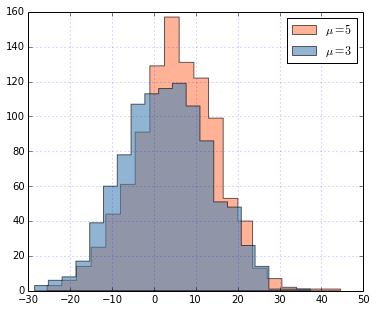

```python
f, ax = plt.subplots(figsize=(6,5))
ax.hist(Xrvs,histtype='stepfilled', bins=20, color='coral', alpha=.6, label=r'$\mu = 5$')
ax.hist(Yrvs,histtype='stepfilled', bins=20, color='steelblue', alpha=.6, label=r'$\mu = 3$')
ax.grid(color='b',alpha=.6)
ax.legend();
```

```python
t, p = stats.ttest_ind(Xrvs, Yrvs)
print("""\n===========================
T statistics = %s ~= %4.2f
P-value = %s ~= %8.6f
===========================
""" % (t, t, p, p))
```

```
===========================
T statistics = 5.27363059993 ~= 5.27
P-value = 1.48218179155e-07 ~= 0.000000
===========================
```

#### Correlation (Pearson's R)

```python
from scipy.stats import pearsonr
```

We're gonna apply that to Time-Series of NINO3.4 and the SOI

The NINO indices come from http://www.cpc.ncep.noaa.gov/data/indices/ersst3b.nino.mth.81-10.ascii

The SOI is in the `data` directory

```python
import os
from datetime import datetime
from dateutil import parser
import pandas as pd
```

```python
nino_url = "http://www.cpc.ncep.noaa.gov/data/indices/ersst3b.nino.mth.81-10.ascii"
```

```python
# if not working try:
nino = pd.read_table('./data/ersst3b.nino.mth.81-10.ascii', sep='\s*', engine='python')
#nino = pd.read_table(nino_url, sep='\s*')
dates = [datetime(x[0], x[1], 1) for x in zip(nino['YR'].values, nino['MON'].values)]
nino.index = dates
```

```python
nino.head()
```

|  | YR | MON | NINO1+2 | ANOM | NINO3 | ANOM.1 | NINO4 | ANOM.2 | NINO3.4 | ANOM.3 |
| --- | --- | --- | --- | --- | --- | --- | --- | --- | --- | --- |
| 1950-01-01 | 1950 | 1 | 23.11 | -1.57 | 23.74 | -2.03 | 27.03 | -1.29 | 24.83 | -1.84 |
| 1950-02-01 | 1950 | 2 | 24.20 | -1.91 | 24.92 | -1.57 | 27.15 | -1.02 | 25.20 | -1.63 |
| 1950-03-01 | 1950 | 3 | 25.37 | -1.13 | 26.33 | -0.91 | 27.06 | -1.23 | 26.03 | -1.30 |
| 1950-04-01 | 1950 | 4 | 23.86 | -1.75 | 26.46 | -1.10 | 27.29 | -1.26 | 26.36 | -1.43 |
| 1950-05-01 | 1950 | 5 | 23.03 | -1.39 | 25.72 | -1.52 | 27.59 | -1.25 | 26.19 | -1.72 |

```python
soipath = './data'
def get_SOI(soipath, start_date='1950-01-01'):
    soi = pd.read_csv(os.path.join(soipath,'NIWA_SOI.csv'), index_col=0)
    soi = soi.stack()
    soi = soi.dropna()
    dates = [parser.parse("%s-%s-%s" % (str(int(x[0])), x[1], "1")) for x in soi.index]
    soidf = pd.DataFrame(soi.values, index=dates, columns=['SOI'])
    soidf = soidf.truncate(before=start_date)
    return soidf
```

creates another DataFrame containing the SOI

```python
df = get_SOI(soipath)
```

```python
df.head()
```

|  | SOI |
| --- | --- |
| 1950-01-01 | 0.570492 |
| 1950-02-01 | 1.642897 |
| 1950-03-01 | 1.745849 |
| 1950-04-01 | 1.895316 |
| 1950-05-01 | 0.748673 |

Will automaticall **ALIGN** the DataFrames, see Pandas.ipynb

```python
df['nino'] = nino['ANOM.3']
```

```python
r, p = pearsonr(df['SOI'], df['nino'])

print("R = {0:<4.2f}, p-value = {1:<4.2f}".format(r,p))
```

```
R = -0.71, p-value = 0.00
```

```python
#df = pd.DataFrame({'SOI':soi['SOI'],'nino':nino['ANOM.3']}, index=nino.index)
```

```python
#df.to_csv('./data/soi_nino.csv')
```

## scipy.interpolate

There are several interfaces for performing 1D, 2D or N Dimensional interpolation using scipy.

For more on that I refer you to

- http://docs.scipy.org/doc/scipy/reference/interpolate.html
- http://wiki.scipy.org/Cookbook/Interpolation

Here we're going to see one simple example in 1D and 2D using [Radial Basis Functions](http://en.wikipedia.org/wiki/Radial_basis_function) using the default (Multiquadric)

#### 1D interpolation

```python
from scipy.interpolate import interp1d
```

```python
x = np.linspace(0, 10, 10)
y = np.sin(x)
```

```python
x
```

```
array([  0.        ,   1.11111111,   2.22222222,   3.33333333,
         4.44444444,   5.55555556,   6.66666667,   7.77777778,
         8.88888889,  10.        ])
```

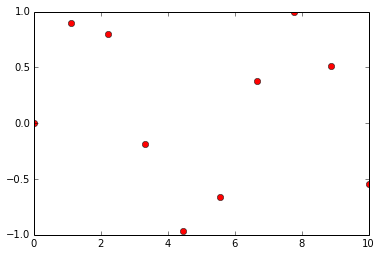

```python
plt.plot(x,y,'ro')
```

```python
f1 = interp1d(x, y) # default is linear
```

```python
f2 = interp1d(x, y, kind='cubic') # and we're gonna try cubic interpolation for comparison
```

```python
xnew = np.linspace(0, 10, 50)
```

```python
ylin = f1(xnew)
ycub = f2(xnew)
```

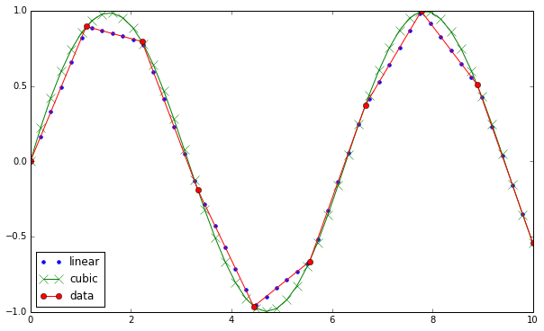

```python
f, ax = plt.subplots(figsize=(10,6))
ax.plot(xnew, ylin, 'b.', ms=8, label='linear')
ax.plot(xnew, ycub, 'gx-', ms=10, label='cubic')
ax.plot(x,y,'ro-', label='data')
ax.legend(loc='lower left')
```

### 2D interpolation using Radial Basis Functions

```python
from scipy.interpolate import Rbf
```

```python
# defines a function of X and Y
def func(x,y):
    return x*np.exp(-x**2-y**2)
```

```python
np.random.seed(1) # we 'fix' the generation of random numbers so that we've got consistent results

x = np.random.uniform(-2., 2., 100)
y = np.random.uniform(-2., 2., 100)

z = func(x,y)

ti = np.linspace(-2.0, 2.0, 100)

XI, YI = np.meshgrid(ti, ti) # meshgrid creates uniform 2D grids from 1D vectors

# use RBF
rbf = Rbf(x, y, z, epsilon=2) # instantiates the interpolator
# you might want to play with the epsilon optional parameter

ZI = rbf(XI, YI) # interpolate on grid
```

```python
# this is the 'True' field, the result of the function evaluated on a regular grid
true_Z = func(XI, YI)
```

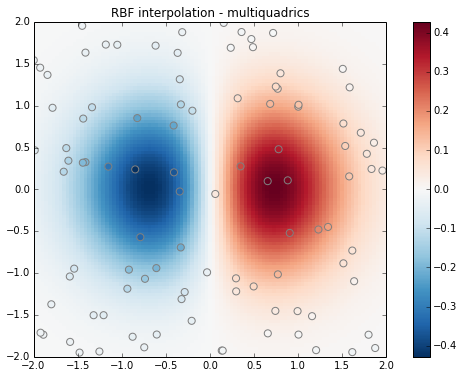

```python
# plot the result
f, ax = plt.subplots(figsize=(8,6))
im = ax.pcolor(XI, YI, ZI, cmap=plt.get_cmap('RdBu_r'))
ax.scatter(x, y, 50, z, cmap=plt.get_cmap('RdBu_r'), edgecolor='.5')
ax.set_title('RBF interpolation - multiquadrics')
ax.set_xlim(-2, 2)
ax.set_ylim(-2, 2)
plt.colorbar(im, orientation='vertical', pad=0.06);
```

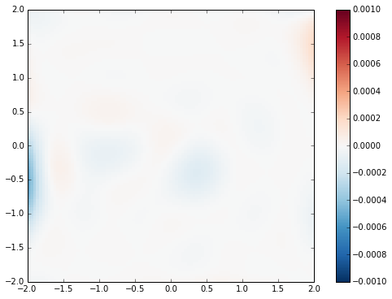

```python
# plot the difference between the 'true' field and the interpolated
f, ax = plt.subplots(figsize=(8,6))
im = ax.pcolor(XI, YI, ZI - true_Z, cmap=plt.get_cmap('RdBu_r'), vmin=-1e-3, vmax=1e-3)
ax.set_xlim(-2, 2)
ax.set_ylim(-2, 2)
plt.colorbar(im, orientation='vertical', pad=0.06);
```

## Curve fitting with scipy.optimize

In this case you want to fit noisy, e.g. experimental, data to **a specific function**, with *unknown parameters*

```python
from scipy.optimize import curve_fit
```

The algorithm uses the [Levenberg-Marquardt](http://en.wikipedia.org/wiki/Levenberg%E2%80%93Marquardt_algorithm) algorithm to perform non-linear least-square optimization

```python
def fitFunc(t, a, b, c):
    """
    defines the function
    takes 3 parameters: a, b and c
    """
    return a*np.exp(-b*t) + c
```

```python
curve_fit?
```

```python
### defines the evaluation domain
t = np.linspace(0,4,50)

### defines the paramaters
a = 5.0
b = 1.5
c = 0.5

### create the response
temp = fitFunc(t, a, b, c)

### add some noise to simulate "real world observations" such as experimental data
noisy = temp + 0.4 * np.random.normal(size=len(temp))

### use curve_fit to estimate the parameters and the covariance matrices
fitParams, fitCovariances = curve_fit(fitFunc, t, noisy)

afit, bfit, cfit = tuple(fitParams)

print("\nEstimated parameters\na: {0:<4.2f}, b: {1:<4.2f}, c: {2:<4.2f}\n\n".format(afit, bfit, cfit))
```

```
Estimated parameters
a: 5.29, b: 1.63, c: 0.52
```

```python
fitCovariances
```

```
array([[ 0.06644151,  0.01898866, -0.00200792],
       [ 0.01898866,  0.02723874,  0.00926891],
       [-0.00200792,  0.00926891,  0.00767782]])
```

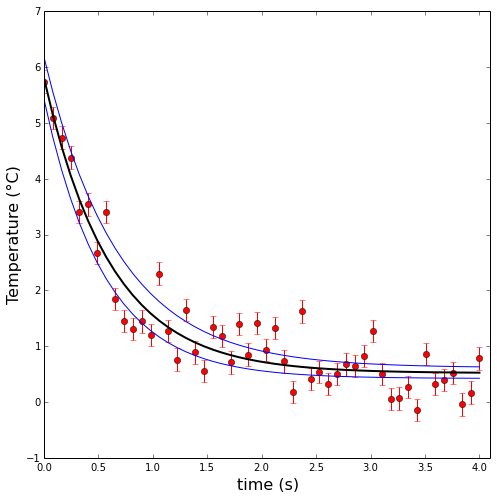

```python
f, ax = plt.subplots(figsize=(8,8))
ax.set_ylabel(u'Temperature (\xb0C)', fontsize = 16)
ax.set_xlabel('time (s)', fontsize = 16)
ax.set_xlim(0,4.1)
# plot the data as red circles with vertical errorbars
ax.errorbar(t, noisy, fmt = 'ro', yerr = 0.2)
# now plot the best fit curve

ax.plot(t, fitFunc(t, afit, bfit, cfit),'k-', lw=2)

# and plot the +- 1 sigma curves
# (the square root of the diagonal covariance matrix
# element is the uncertainty on the fit parameter.)

sigma_a, sigma_b, sigma_c = np.sqrt(fitCovariances[0,0]), \
np.sqrt(fitCovariances[1,1]), \
np.sqrt(fitCovariances[2,2])

ax.plot(t, fitFunc(t, afit + sigma_a, bfit - sigma_b, cfit + sigma_c), 'b-')
ax.plot(t, fitFunc(t, afit - sigma_a, bfit + sigma_b, cfit - sigma_c), 'b-');
```